# Exercicios sala

# Aula 2

## Datas

1. Escreva um código que armazene uma data qualquer e a imprima nos seguintes formatos: `20/10/2023 10h`, `20-10-23 10:20`, `10/23 10h20min`,
2. Escreva um código que armazene a data atual e a imprima nos formatos (mesmo do exercicio anterior): `20/10/2023 10h`, `20-10-23 10:20`, `10/23 10h20min`
3. Escreva um código que pergunte a data de nascimento do usuário, em seguida informe quantos anos o usuário tem, em anos como um número real (o código deve funcionar em qualquer ano que seja utilizado).
4. Escreva um código que pergunte a data de nascimento do usuário e informe em qual dia da semana será seu aniversário esse ano (o código deve funcionar em qualquer ano que seja utilizado).

## Condicionais

1. Faça um algoritmo para receber um número qualquer do usuário e informar na tela se é par ou ímpar
2. Tendo como dados de entrada a altura, o sexo (M/F) e a massa (Kg) de uma pessoa. Construa um algoritmo que calcule seu peso ideal, utilizando as seguintes fórmulas:
- para homens: (72.7 * h) – 58;
- para mulheres: (62.1 * h) – 44.7

Em seguida informe se o peso do usuário está acima, abaixo ou exatamente no peso ideal. 3. Considere uma frase fornecida pelo usuário. Se o usuario não digitar nada, mostre a mensagem “Você não digitou nada…” e pare o programa. Se uma mensagem foi digitada, verifique qual das três vogais (a,e,i) ocorre mais vezes na frase, e informe ao usuário.

3. Considere o exercício de encontrar o dia da semana do aniversário do usuário (ex. 4 de Datas). Atualize o código para que o dia da semana encontrado seja mostrado em PT-BR.

## Laço *for*

1. Considerando a lista abaixo, faça o que se pede:

```python
l = [1,3,-1,10,5,20]
```

- Imprima todos os elementos da lista usando as duas formas do laço for.
- Verifique quantos elementos negativos existem na lista e informe ao usuário (se existem (quantos) e se não existem).
- Informe quantos elementos existem na lista.
- Imprima os elementos da lista de forma reversa.
3. Calcule a soma de todos os números pares de 0 a 100 e mostre o resultado na tela.
4. Escreva um código que pergunte a data de nascimento do usuário e informe em qual dia da semana será seu aniversário nos próximos 20 anos. Imprima o ano e o dia da semana.

## Laço *While*

1. Considere a seguinte lista de strings:

```python
l_string = ["Quantas","palavras","cabem","em","uma","lista?"]
```

- Imprima os elementos da lista usando um laço while.
- Imprima os elementos da lista com letras maiusculas usando um laço while.
2. Crie um algoritmo que receba numeros inteiros positivos do usuário, até o momento em que ele digite -1. Ao fim do programa mostre a soma de todos os números digitados e qual foi o maior deles.

# Aula 3

## Tuplas

- Crie uma tupla com os 100 primeiros números ímpares positivos.
- Atribua os 4 primeiros valores da tupla nas variáveis A,B C e D, usando o desempacotamento.
- Some os 4 valores (A,B,C e D), e atribua a soma nos 4 primeiros elementos da tupla.
- Finalmente, encontre a soma de todos os elementos da nova tupla.

## Listas

1. A lista abaixo mostra um conjunto de cidades:

```python
l_cidades = ["Piracicaba", "Bauru", "Curitiba", "Maringa", "Londrina"]
```

Um algoritmo de roteirização foi executado determinando a ordem de visita de cada uma das cidades (por seus indices), na lista abaixo:

```python
l_rota = [1,0,2,4,3]
```

Imprima a rota das cidades que deve ser seguida.

2. Considere a lista abaixo:

```python
l_neg = [10,20,-1,-3,5,-1,10,-2]
```

```
2.1 Remova todos os elementos -1 da lista
2.1 Remova todos os elementos negativos da lista (com a lista reinicializada)
```

3. (pos fatiamento) Considere a lista abaixo:

```python
l1 = [0,1,2,3,4,5]
```

Imprima os elementos como uma escada: [] [0] [0,1] [0,1,2] …

4. (pos fatiamento e sum) Considere os dados de vendas de um produto como mostrado na lista abaixo:

```python
l_vendas = [20,19,18,16,16,19,22,23]
```

Faça uma estimativa de vendas para os próximos 3 períodos usando o método das médias-móveis, com 4 períodos anteriores.

5. (pos matriz). A matriz abaixo representa as atividades de um projeto e suas dependencias. As linhas e colunas representam atividades, e o valor 1 indica que a atividade da linha precede a atividade da coluna. A última atividade é a 4 (começando em 0). O vetor T indica o tempo de processamento que cada atividade leva para ser completada. Considerando um projeto que deve terminar no periodo 5, e estamos no periodo 1, verifique se com a configuração atual é possível executar o projeto a tempo.

```python
T = [1,1,1,1,1]
M =  [[0,0,1,0,0],
      [0,0,0,0,1],
      [0,1,0,1,0],
      [0,0,0,0,1],
      [0,0,0,0,0]]
```

A precedência de atividades fica:

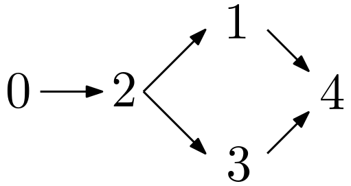

## Dicionários

1. Crie um dicionário com as seguintes marcas de carros e seus preços: Honda:40000 Toyota:20000 Chevrolet:25000 Peça ao usuário o input de um carro e, se o mesmo existir, mostre o seu valor. Se não,pergunte se o usuário gostaria de cadastrar o novo veículo. Colete o valor do veículo e adicione no dicionário. Ao final imprima o dicionário completo.
2. Considere uma indústria que fabrica 4 tipos de pães de queijo: P1,P2,P3 e P4. Cada “batelada” (ordem de produção) de um tipo de pão é salvo em uma lista. A lista abaixo mostra as bateladas em um dia:

```python
l_paes = ["P1","P1","P2","P3","P4","P4","P2","P1","P3"]
```

Quantas bateladas foram feitas de cada tipo de pão de queijo?

3. Considere uma industria que fabrica 4 tipos de pães de queijo: P1,P2,P3 e P4. O setor de PCP armazena as quantidades produzidas, horas de inicio e fim e quantidades de cada batelada em um banco de dados:

```python
l_paes = ["P1","P1","P2","P3","P4","P4"]
l_inicios = ["08:20","08:40","09:05","09:30","09:56","11:00"]
l_terminos = ["08:25","08:58","09:25","09:55","10:56","13:50"]
l_qtde = [500,420,400,450,800,900]
```

Considere que só existe uma masseira. Responda o que se pede:

- Quais foram os tempos totais de produção de cada pão na masseira (em minutos)?
- Quantas vezes cada pão foi executado na masseira?
- Qual foi o rendimento total (em kg) de cada pão?

## List comprehension

1. Verifique se as seguintes séries são convergentes ou não, usando list comprehensions. 1.1 $\frac{1}{n}$ 1.2 $\frac{1}{2^n}$
2. Considere a seguinte lista com diversos valores:

```python
l_poluida = ["Azul","Amarelo","5","Verde","10","3"]
```

Separe os dados em duas listas, uma com as palavras salvas de forma maiúscula, e uma com os números (transformados em números). Imprima o número de palavras e a soma dos números. - Faça usando for E list comprehension (.isdigit)

3. Considere a seguinte lista:

```python
l_palavras = ["Será", "palavras","que","carro azul","deu","Submarino amarelo","certo?"]
```

Filtre somente as palavras com menos do que 7 caracteres e salve em uma lista (usando list comprehensions)

4. Crie as duas matrizes abaixo usando list comprehensions:

```python
M = [[1,1,1],
[2,2,2],
[3,3,3]]
M = [[0,0,0,0],
[0,0,0,0],
[0,0,0,0]]
```

5. Considere a seguinte matriz:

```python
M = [[1,-1,1], [-2,2,2], [3,3,-3]]
```

Crie uma lista somente com os elementos negativos da matriz, use list comprehension

6. (Pós list comprehension e dicionários) Você quer criar um tradutor de sentenças de en para pt. Use dicionários para traduzir a seguinte sentença:

```python
sentenca = "O que você quer que eu traduza?"
```

## Funções

1. O controle de qualidade de uma empresa mede o diametro de uma peça, salvando os valores na seguinte lista:

```python
l_diam = [0.8, 0.7 ,0.7 ,0.3,0.75]
```

Cada medição feita por um funcionário:

```python
l_func = ["Febo","Diana","Cástor","Pólux","Diana"]
```

Crie uma função que retorne uma lista com o nome dos funcionários cujas medições ficaram abaixo da média da amostra (se possível use list comprehension para reduzir o código).

2. Crie uma função que receba duas matrizes numéricas, realize a soma das mesmas e retorne a nova matriz. Se as matrizes não puderem ser somadas (por divergência em suas dimensões), a soma não é realizada e o usuário deve ser informado. DICA: Tuplas podem ajudar muito no retorno das funções e parâmetros como um dicionário.
3. Crie uma função que calcule integrais definidas. A função deve permitir o cálculo da integral de quaisquer funções.
4. Crie uma função (`f_raiz`) que calcule pelo menos uma raiz de uma função (f) usando o método da bissetriz. O usuário deve passar os valores iniciais de `a` e `b`. Passe a função f como argumento da `f_raiz`.

# Aula 4 - Numpy

## Arrays

1. Considerando o ex. para o calculo de integrais. O usuário definiu o intervalo de integração (a,b). Crie o vetor de elementos x usando arrays e o método .arange()

## Random

1. Simule o processo de 2 pessoas jogando “par ou impar” 10 vezes. Quantas vezes par ganhou? Quantas vezes impar ganhou?
2. Simule o processo do jogo da “parede”, em que uma bola é lançada, e a cada etapa ela vai para direita ou esquerda com mesma probabilidade. No fim de cada caminho está um premio, existem 5 camadas de “decisões” e os caminhos são numerados [0,1,2,3,4,5,6,7,8,9,10]. A bola cai a partir do caminho 5, se a pessoa acertar os caminhos 2, 8 ou 10 ela ganha um prêmio. Considere que a pessoa pode tentar 3 vezes. Ela ganha o premio ou não?
3. Considere o algoritmo da bisseção feito nas ultimas aulas. Nele o usuário digitava os valores de a e b iniciais. Crie uma função em que esses argumentos são opcionais. Se o usuário não os digitar, encontre valores adequados de a e b.

## Operações aritméticas

1. Uma empresa de cereais possui 5 funcionários. A produção mensal de cada funcionário, bem como seus nomes, são dados pelas listas:

```python
func = ["Jerry","Newman","George","Kramer","Bania"]
prod = [200,100,99,120,134]
```

Usando arrays numpy responda o que se pede: * Qual foi a produção total? * Qual foi a média de produção? * Qual foi a maior produção? E a menor? * Quais foram os funcionarios que as fizeram?

2. Crie uma função que realize a soma de duas matrizes (de arrays) M1 e M2.Gere as duas matrizes aleatoriamente com valores inteiros aleatórios entre 5 e 10. OBS: Usar try: except: para coletar erros no código.
3. Considere a matriz criada da seguinte forma:

```python
import numpy as np
M = np.random.randint(2,4, size = (4,5) )
```

- Qual é a soma de todos os elementos da matriz?
- Qual a soma dos elementos por linhas?
- Qual a soma dos elementos por colunas?

## Fatiamento

1. Exercicio 13 da lista
2. A matriz criada da seguinte forma:

```python
import numpy as np
M    = np.random.randint(3,9, size = (4,5) )
```

Indica a produção de 4 máquinas (linhas) durante o período de 5 dias (colunas). Sejam as máquinas e os dias armazendos em duas listas:

```python
dias = ["seg","ter","qua","qui","sex"]
maq  = ["M1","M2","M3","M4"]
```

Responda o que se pede:

- Qual foi o total produzido na semana?
- Qual foi o total produzido por dia
- Qual foi o total produzido por máquina?
- Qual foi o dia com a maior produção?
- Qual foi a máquina com a maior produção?
- Qual foi o total de produção da terça-feira? E da quarta?
- A empresa precisa atualizar os dados da seguinte forma:
  1. Toda a produção de sexta feira deve ser = 5
  2. Toda a produção da máquina 4 (exceto na sexta) deve ser nula

## Indexação booleana

0. Ex. pães
1. Considere as vendas de uma empresa salvas em 2 listas, uma de datas e uma de valores:

```python
l_datas   = ["2022/01/01","2022/02/01","2022/02/02","2022/01/01","2022/03/01"]
l_valores = [300,200,400,200,500]
```

Quais foram as vendas do mês de fevereiro?

2. O algoritmo Simplex encontra o elemento pivo a cada iteração, como a coluna do mínimo (negativo) da fo e o minimo de $\frac{b}{A_i}$, com $A_i > 0$. Considere o PL abaixo:

```python
M = np.array( [[-1,-2,0,0,0,0],
              [1,1,1,0,0,6],
              [1,-1,0,1,0,4],
              [-1,1,0,0,1,4]])
```

Encontre o elemento pivô para o problema acima.

3. Desafio: termine a implementação do algoritmo simplex (executar o pivoteamento na tabela e reaplicar a rotina de encontrar o elemento pivô, até o momento em que não existam $c < 0$)

# Aula 4 - Pandas

1. Crie um DataFrame com 5 colunas, cada coluna deve ter 20 valores gerados aleatoriamente a partir da dist. uniforme, entre os intervalos:
- col1: [0,10]
- col2: [11,20]
- col3: [21,30]
- col4: [31,40]
- col5: [41,50]

Adicione uma nova coluna chamada “soma”, com a soma dos elementos de cada linha.

2. Crie um dataframe a partir de uma matriz 4x5 gerada aleatóriamente com valores entre 2 e 9. As colunas devem ter os nomes: `["seg","ter","qua","qui","sex"]` e as linhas(maquinas) `["M1","M2","M3","M4"]`.
- Mostre produção total da semana.
- Mostre produção total da semana por máquinas.
- Mostre produção total da semana por dias.
- Mostre qual foi o dia da semana com a maior produção total.
3. Considere as informações a seguir, dadas por listas, de uma famosa empresa que vende papel:

```python
nomes            = ["Angela","Dwight","Michael","Stanley","Jim"]
vendas           = [0       ,300     , 150     ,   29    , 286]
dias_trabalhados = [25      , 20     , 25      ,   25    ,  19]
faltas           = [0      , 0       , 1       ,   2     ,  2]
```

- Crie um DataFrame com os dados, e responda as perguntas a partir do dataframe.
- Qual foi o funcionário com a maior venda?
- Crie uma nova coluna com a proporção de vendas/dias trabalhados, chamada produtividade.
- Qual foi o funcionário com a maior produtividade?
- Quais os funcionários que não tiveram faltas no periodo?
- Quais os funcionários que tiveram 0 ou 2 faltas?
- Acesse as faltas e a produtividade dos funcionário Dwight e Michael, usando FATIAMENTO no df
- Exporte o dataframe criado
4. Considerando o conjunto de dados “clientes_shopping.csv”, responda:
- Quantos homens e quantas mulheres estão no bd?
- Qual é a média de idade das pessoas no bd, e de rendimento anual?
- Qual é a porcentagem de mulheres que ganham acima da média, e de homens?
5. Considerando o conjunto de dados “Production_Data”, responda o que se pede:
- Quantas OP foram processadas?
- Quantos produtos diferentes existem no bd?
- Considerando a atividade “Turning & Milling - Machine 4”,

  5.1 qual OP teve o processo com a maior quantidade completada?

  5.2 qual foi o funcionário que a realizou?

  5.3 qual foi a peça processada?

  5.4 Quanto tempo (em horas), a máquina ficou em processamento?

  5.5 Considerando todas as vezes que a máquina foi usada, qual foi o tempo médio de processamento (em horas)?

# Aula 5 Matplotlib

1. Considerando o conjunto de dados Production_Data.csv, faça o que se pede:
- Gere um gráfico de barras com a média dos tempos de processamento para cada Atividade (em horas).
- O gráfico deve possuir nomes nos eixos e título.
- A média de processamento considerada tolerável para as máquinas é de 7 horas. Coloque essa informações no gráfico de forma que fique fácil visualizar quais máquinas não estão conforme.
- Ajuste o gráfico para que seja possível visualizar os nomes das atividades no eixo x.
3. Considerando o conjunto de dados “clientes_shopping.csv”, faça:
- Crie um gráfico de pizza com a proporção de mulheres e de homens no banco de dados. Crie um código que exploda a maior proporção de forma automática (em função da maior proporção).
4. Considerando o conjunto de dados “producao_grega.csv”, com registros da produção de vasos gregos: Existem alguns tipos de defeitos associados à produção. A gerencia gostaria de saber quais defeitos devem ser tratados primeiro. Responda essa pergunta por meio de uma análise de gráfico de Pareto.
- Crie um gráfico de Pareto considerando que o custo dos defeitos é diretamente proporcional à sua frequencia de ocorrencia.
- marque no gráfico as linha de frequencia acumulada: 70%, 80% e 90%
5. Considerando o conjunto de dados “producao_grega.csv”, e o vaso chamado “peça2”. Suspeita-se de que a temperatura do dia pode influenciar a medição dos vasos. Como você faria para extrair mais informações a esse respeito e tomar uma decisão, usando um gráfico? Qual a sua decisão? Crie o gráfico que suporte o seu raciocinio.
6. Considerando o conjunto de dados “Iris.csv”, com informações a respeito de comprimentos e larguras da pétala e sépala de 3 tipos de flores Iris. Dê um palpite sobre qual pode ser a distribuição de dados do comprimento da sépala par a flor do tipo “Iris-setosa”. Paute sua decisão gráficamente.